# 📊 S&P 500 Trends Analysis

The **S&P 500** is an index that tracks the top 500 companies listed on the stock exchanges in the United States. Understanding the trends in the index can help provide insight into market trends and economic conditions.

An index is a collection of assets such as stocks, bonds, commodities, and etc that represent a performance of a market or sector. Within this research project my goal is to understanding the change of the S&P 500 through trends and patterns and examine which stocks represent a broader index of the S&P 500.

The dataset used from Kaggle: [S&P 500 + Popular Stocks: Daily Trends & % Change](https://www.kaggle.com/datasets/atacs26/s-and-p-500-popular-stocks-daily-trends-and-change/code)

[Link to Notebook File](https://github.com/ToyaOkey/ToyaOkey.github.io/blob/main/s%26p500view.ipynb)

### Objectives

The dataset highlights:

- `Date`: The dataset includes trading data from 2012 to 2021
- `sp500_changep`: The percentage chance in the S&P 500 index.
- Individual stock data for major companies (i. e) **Microsoft (MSFT), Tesla (TSLA), NVIDIA (NVDA), Netflix (NFLX)**

Each stock has two columns: one representing whether the stock increased in value on a given day (0 or 1), and another recording the percentage change in stock price (`changep`). The dataset shares a valuable exploration of individual stock behaviors and how different stocks interact with the index.

### **Key Questions**

1. How has the S&P changed over time?
2. Are there any noticeable trends or patterns?
3. How do individual stocks compare to the broader index?

### Additional Questions

1. Which stock showed the highest average daily percentage increase?
2. Which stock is most correlated with the S&P 500?
3. Which stock serves as the best predictor for S&P 500 movements?
4. How do technology stocks compare to entertainment stocks?
5. Can trends in individual stocks help predict the S&P 500?

The goal of this project to analyze different trends within the S&P 500 and the comparision between various tech and entertainment stocks, to help identify patterns in movements within the market. By exploring these trends I hope to determine wether specific stocks show strong correlations with the strength in the S&P 500 and whether they show as market predictors, Additionally the main thing I like to examine is the behavior of technical stocks compared to entertainment stocks, examining growth trends, volatility, and influence on the market.

With examining these relationships I hope to help investors and analysts in making informed decisions and give more guidance on information regarding the S&P 500. Additionally the comparison between technology and entertainment stocks provides insights into which sectors can experience more longevity in growth compared to other fluctuations.

# Importing Libraries and Dependencies

In this analysis, we will import a dataset this dataset will explore the trends within **the S&P 500**

```python
# importing libraries
import pandas as pd
import numpy as np
import matplotlib.pyplot as plt
import seaborn as sns
```

# The Data

```python
# configuring the plots
plt.style.use("ggplot")

# reading the data
data = pd.read_csv("sp500_trends.csv")

# preview data
data.head()
```

|  | Unnamed: 0 | Date | sp500_increase | sp500_changep | ADBE_increase | ADBE_changep | INTC_increase | INTC_changep | MSFT_increase | MSFT_changep | ... | DIS_increase | DIS_changep | NFLX_increase | NFLX_changep | TSLA_increase | TSLA_changep | META_increase | META_changep | KFC_increase | KFC_changep |
| --- | --- | --- | --- | --- | --- | --- | --- | --- | --- | --- | --- | --- | --- | --- | --- | --- | --- | --- | --- | --- | --- |
| 0 | 0 | 2021-04-19 | 0 | -0.252251 | 0 | -1.330457 | 0 | -1.653780 | 0 | -0.557290 | ... | 0 | -0.042665 | 1 | 1.378676 | 0 | -0.690660 | 0 | -0.908173 | 1 | 0.096339 |
| 1 | 1 | 2021-04-16 | 1 | 0.002399 | 1 | 0.165963 | 0 | -0.887803 | 1 | 0.489455 | ... | 0 | -0.165278 | 0 | -0.726559 | 1 | 1.527485 | 0 | -0.645754 | 1 | 0.241546 |
| 2 | 2 | 2021-04-15 | 1 | 0.514817 | 1 | 1.469936 | 1 | 1.641387 | 1 | 0.608695 | ... | 0 | -1.148388 | 1 | 0.928017 | 0 | -0.571924 | 1 | 0.483127 | 1 | 0.096712 |
| 3 | 3 | 2021-04-14 | 0 | -0.334272 | 0 | -0.655641 | 0 | -1.714891 | 0 | -0.734043 | ... | 1 | 0.801207 | 0 | -2.676298 | 0 | -4.991566 | 0 | -1.457853 | 1 | 0.241663 |
| 4 | 4 | 2021-04-13 | 1 | 0.323181 | 1 | 1.580345 | 0 | -0.594421 | 1 | 0.478108 | ... | 0 | -0.053877 | 0 | -0.587077 | 1 | 6.962260 | 0 | -0.784722 | 1 | 0.828057 |

5 rows × 24 columns

# Scrubbing / Cleaning of the Data

Before analysis it is important to clean the data to remove any null values or uncessary information.

The first step was to remove missing values from the dataset to prevent biased calculations, where inconsistences such as missing stock values, could distort trends and lead to incorrect conclusions. The next step is to remove any empty rows within the dataset, then check for any duplicate or missing data.

## Converting and Fixing Formats

After removing the null values from the dataset the `Date` column is converted into the proper datetime format for the computer to understand the date compared to plaintext format. The next step is to sort the information by date to ensure the table is in earliest to latest format. The last step is to show the details of the columns and the rows and explaining the datatype of each column.

## Cleaning and Displaying Data Types

```python
# Cleaning
df = data

df.drop(columns=["Unnamed: 0"], inplace=True) if "Unnamed: 0" in df.columns else None
df = df.dropna()
df.isnull().sum()
df.duplicated().sum()
df["Date"] = pd.to_datetime(df["Date"])
df.sort_values(by="Date", inplace=True)

df.info()
```

```
<class 'pandas.core.frame.DataFrame'>
Index: 2128 entries, 2127 to 0
Data columns (total 23 columns):
 #   Column          Non-Null Count  Dtype
---  ------          --------------  -----
 0   Date            2128 non-null   datetime64[ns]
 1   sp500_increase  2128 non-null   int64
 2   sp500_changep   2128 non-null   float64
 3   ADBE_increase   2128 non-null   int64
 4   ADBE_changep    2128 non-null   float64
 5   INTC_increase   2128 non-null   int64
 6   INTC_changep    2128 non-null   float64
 7   MSFT_increase   2128 non-null   int64
 8   MSFT_changep    2128 non-null   float64
 9   AMD_increase    2128 non-null   int64
 10  AMD_changep     2128 non-null   float64
 11  NVDA_increase   2128 non-null   int64
 12  NVDA_changep    2128 non-null   float64
 13  DIS_increase    2128 non-null   int64
 14  DIS_changep     2128 non-null   float64
 15  NFLX_increase   2128 non-null   int64
 16  NFLX_changep    2128 non-null   float64
 17  TSLA_increase   2128 non-null   int64
 18  TSLA_changep    2128 non-null   float64
 19  META_increase   2128 non-null   int64
 20  META_changep    2128 non-null   float64
 21  KFC_increase    2128 non-null   int64
 22  KFC_changep     2128 non-null   float64
dtypes: datetime64[ns](1), float64(11), int64(11)
memory usage: 399.0 KB
```

# Visualizations: Trends Over Time

With understanding the trends in overall market trends, percentage changes will be visualized in the index to identify major spikes and drops and any long term trends.

## Trends within the S&P 500

The first examination is a line plot created to visualize the changes within the S&P 500 index over time specifically the daily changes in the index, allowing us to examine the long-term growth patterns while identifying the market downturns or rapid growth periods, for example from 2020 - 2021 there shows a lot of positive change while also showing negative change within the index.

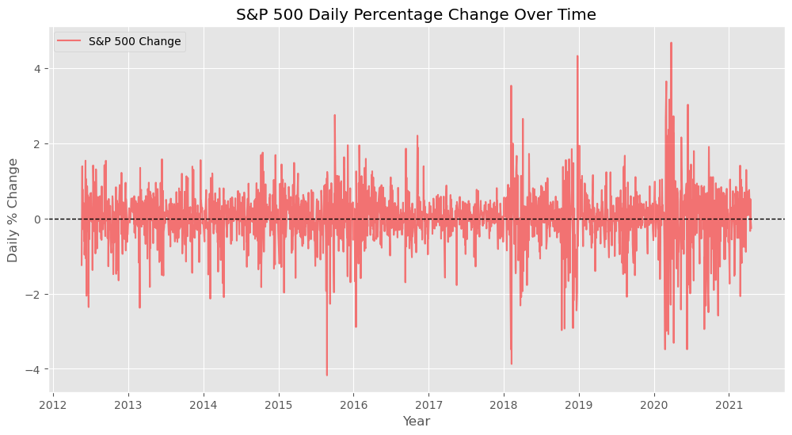

```python
plt.figure(figsize=(12, 6))
sns.lineplot(x=df['Date'], y=df['sp500_changep'], label="S&P 500 Change", color="red", alpha=0.5)

plt.axhline(0, color="black", linestyle="--", linewidth=1)
plt.title("S&P 500 Daily Percentage Change Over Time")
plt.xlabel("Year")
plt.ylabel("Daily % Change")
plt.legend()
plt.show()
```

## Daily Changes vs Moving Average

The next graph represents the changes in the S&P 500 daily change compared to the moving average. The **moving average** calculation to analyze data points by creating a series of averages of different selections of the full data set; the moving average helps analysts and investors investigate a direction of a trend. Showing the comparision of the index compared to the moving average shows the normal changes with the moving average compared to the volatility on some of the days. Examining the graph we can see that some years such as from 2015 - 2016 show a deviation from the moving average in a negative daily change trend and the beginning of 2018 shows a deviation from the moving average in a drastic positive and negative change aspect. The `sp500_changep` column is average to see a daily change in the market over the period from 2012 to 2021, with also the `sp500_ma` column that shows the moving average over a 30 day period.

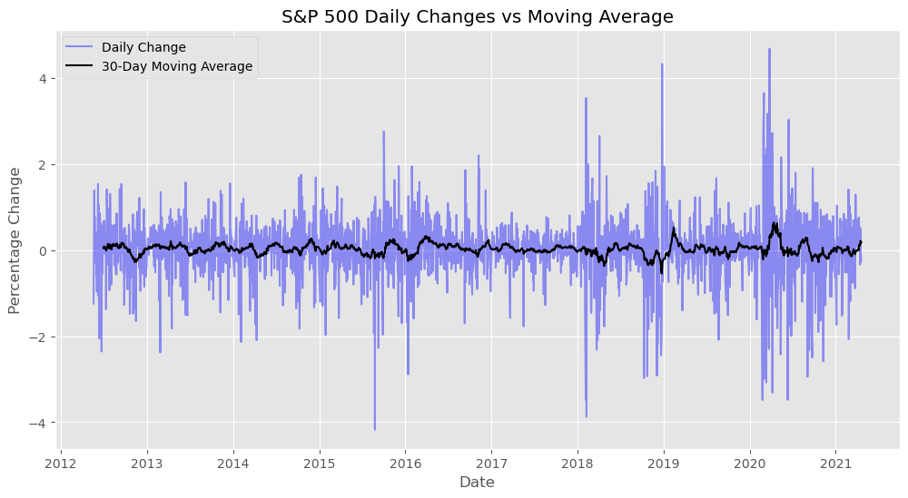

```python
plt.figure(figsize=(12,6))
df['sp500_ma'] = df['sp500_changep'].rolling(window=30).mean()
plt.plot(df['Date'], df['sp500_changep'], alpha=.4, label='Daily Change', color='blue')
plt.plot(df['Date'], df['sp500_ma'], label='30-Day Moving Average', color='black')
plt.xlabel('Date')
plt.ylabel('Percentage Change')
plt.title('S&P 500 Daily Changes vs Moving Average')
plt.legend()
plt.show()
```

## Bubble Chart Representation of Stock Movements

The next visualization is a bubble chart representation of different stock price movements using the `changep` column. The stocks represented are:

- `ADBE`: Adobe Inc. (Technology)
- `INTC`: Intel Corp. (Technology)
- `MSFT`: Microsoft (Technology)
- `AMD`: AMD (Technology)
- `NVDA`: Nvidia (Technology)
- `DIS`: Disney (Entertainment)
- `NFLX`: Netflix (Entertainment)
- `TSLA`: Tesla (Technology)
- `META`: META Technologies (Technology)
- `KFC`: KFC (Food)

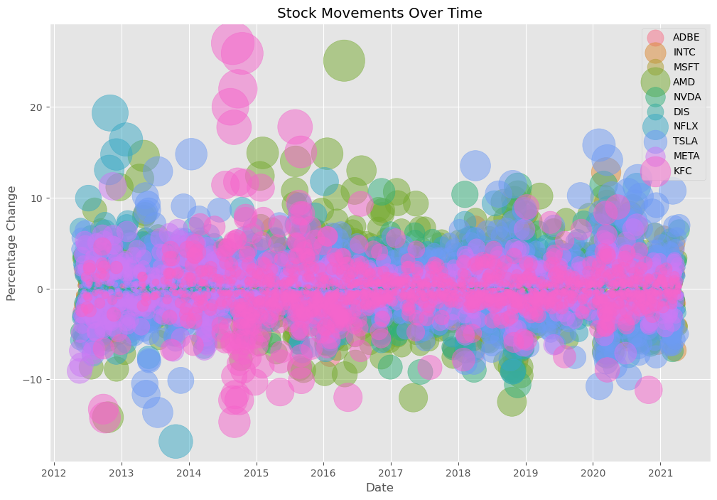

```python
plt.figure(figsize=(12,8))
stocks = ['ADBE_changep', 'INTC_changep', 'MSFT_changep', 'AMD_changep', 'NVDA_changep', 'DIS_changep', 'NFLX_changep', 'TSLA_changep', 'META_changep', 'KFC_changep']
colors = sns.color_palette('husl', len(stocks))

# tracks index and individual stock
for i, stock in enumerate(stocks):
    # make size proportional to the change of the stock
    sizes = np.abs(df[stock]) * 70
    # plot the indivual stock and set color to color of stock from the color list
    plt.scatter(df['Date'], df[stock], s=sizes, alpha=0.5, label=stock.replace("_changep", ""), color=colors[i])

plt.xlabel('Date')
plt.ylabel('Percentage Change')
plt.title('Stock Movements Over Time')
plt.legend()
plt.show()
```

## Boxplot: Stock Volatility (change over time)

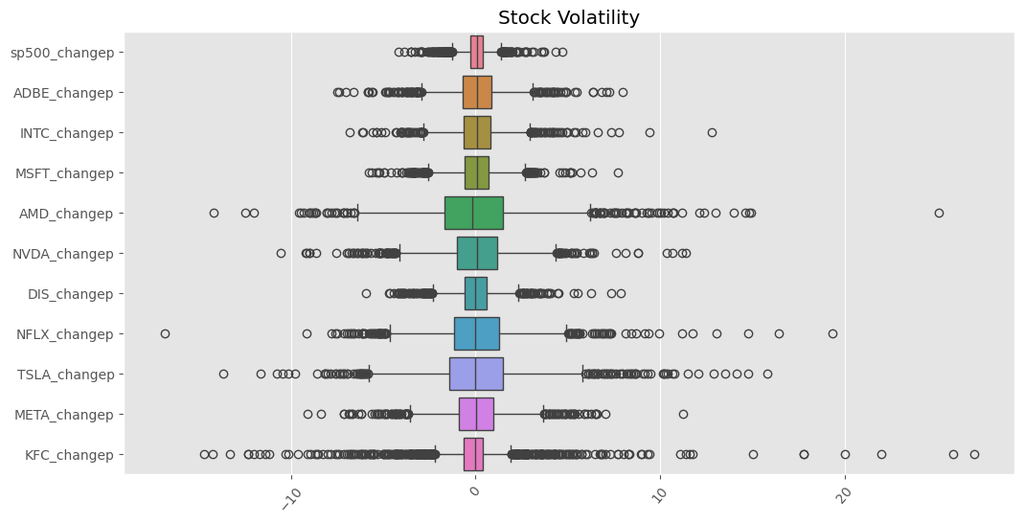

```python
plt.figure(figsize=(12,6))
sns.boxplot(data=df[[col for col in df.columns if 'changep' in col]], palette='husl', orient='h')
plt.xticks(rotation=50)
plt.title('Stock Volatility')
plt.show()
```

## Stock Trends Over Time

This next visualization is very similar to the previous representing the change of individual stocks the plot here adds onto the percentage change and shows the individual stock changes over time. This plot now gives a closer look to the original tables highlighting the percentage increase of the S&P 500 which gives a better examination of which stocks closely correlation with the movement of the index or can predict a trend within the index. Examining this plot it seems that TSLA shared a matchup to the changes within 2020 - 2021 and additionally META seemed to have a stable percentage change within the index.

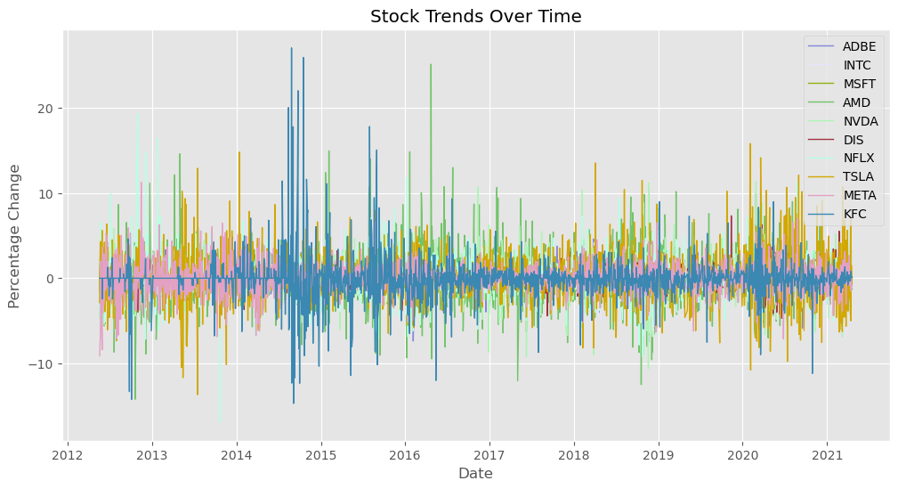

```python
plt.figure(figsize=(12,6))
for stock in stocks:
    plt.plot(df['Date'], df[stock], label=stock.replace("_changep", ""), linewidth=1, color=[np.random.rand(), np.random.rand(), np.random.rand()])
plt.xlabel('Date')
plt.ylabel('Percentage Change')
plt.title('Stock Trends Over Time')
plt.legend()
plt.show()
```

## Distribution of Stock Returns

The distribution of stock returns highlights the likelihood that a stock may generate a return in the market, essentially a profit on an initial investment. For this examination a **Kernel Density Plot (KDE)** is used to visualize the returns of multiple stocks in comparision using the percentage changes. The density represents an **estimated probability distribution** of stock percentage changes. Higher density values indicate frequent percentage changes, while lower values suggest less frequent movements. A wider curve implies higher volatility, whereas a narrower curve indicates more consistent returns. For example, the `TSLA` stock seems to share a lower density but a wider curve suggests a more volatile which means more spread out returns over time. A stock like `DIS` seems to share a narrow distribution meaning that there is a more consistent return while also have a higher percentage in change.

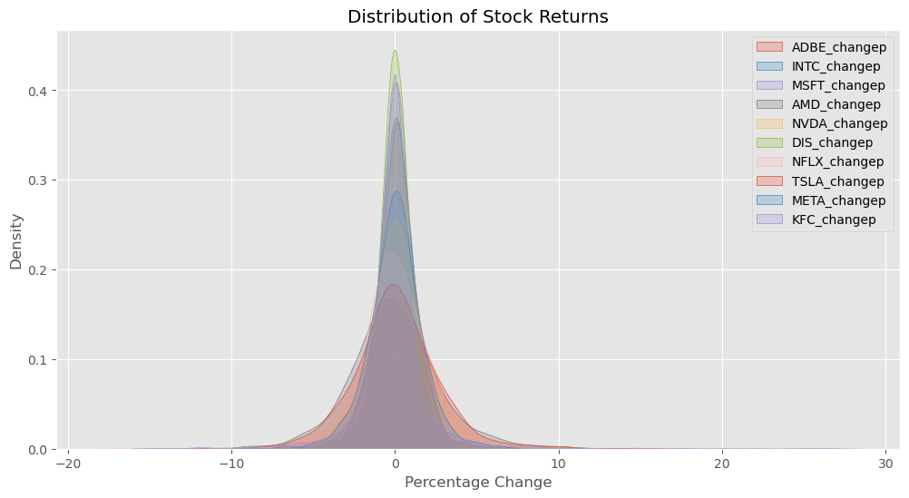

```python
plt.figure(figsize=(12,6))
for stock in stocks:
    sns.kdeplot(df[stock], label=stock, fill=True)
plt.xlabel('Percentage Change')
plt.ylabel('Density')
plt.title('Distribution of Stock Returns')
plt.legend()
plt.show()
```

## Entertainment vs. Technology Stocks

### Percentage Change Visualization

A comparative analysis was beformed between two main factors of *Entertainment and Technology* to see which section could have more of an influence of the S&P 500. The evaluate the performance two plots were created looking at the average percentage changes between the technology stocks (`ADBE, INTC, MSFT, AMD, NVDA, META`) compared to the entertainment stocks (`DIS, NFLX`). One limitation of this examation if the amount of technology stocks represented is over twice the amount of entertainment stocks.

With the examination of the plot it seems that the technology and entertainment almost align during most time periods however there seems to be some deviations like mid to late 2014 with the entertainment section showing a widespread positive change. Additionally in early 2020 with the technology section showing a positive change for technology over entertaiment.

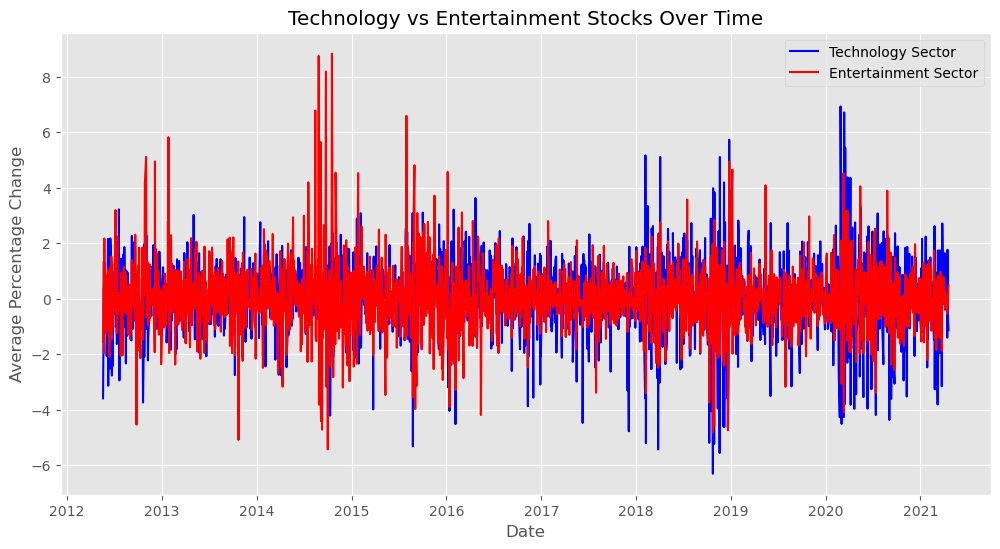

```python
tech_stocks = ['ADBE_changep', 'INTC_changep', 'MSFT_changep', 'AMD_changep', 'NVDA_changep', 'META_changep']
entertainment_stocks = ['DIS_changep', 'NFLX_changep']

plt.figure(figsize=(12,6))
plt.plot(df['Date'], df[tech_stocks].mean(axis=1), label='Technology Sector', color='blue')
plt.plot(df['Date'], df[entertainment_stocks].mean(axis=1), label='Entertainment Sector', color='red')
plt.xlabel('Date')
plt.ylabel('Average Percentage Change')
plt.title('Technology vs Entertainment Stocks Over Time')
plt.legend()
plt.show()
```

### Bar Plot: Comparision of Technology and Entertainment Stocks

The next visualization is a comparision of the average percentage change in Technology stocks and the average percentage change in Entertainment stocks in a bar plot side by side. The averages of `changep` column each of the entertainment stocks and the technology stocks were both taken and displayed within the bar plot, including all of the positive and all of the negative changes. The overall the consensus shows that the entertainment stocks shows a higher average change compared to the technology stocks.

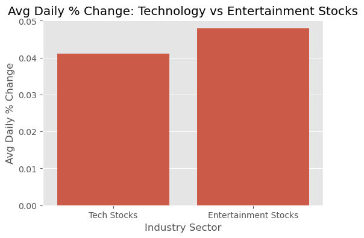

```python
# average for each sector
tech_avg = df[tech_stocks].mean().mean()
entertainment_avg = df[entertainment_stocks].mean().mean()

plt.figure(figsize=(6, 4))
sns.barplot(x=["Tech Stocks", "Entertainment Stocks"], y=[tech_avg, entertainment_avg])
plt.title("Avg Daily % Change: Technology vs Entertainment Stocks")
plt.ylabel("Avg Daily % Change")
plt.xlabel("Industry Sector")
plt.show()
```

## Stock Performance vs S&P 500

The last visualization is to represent each stocks comparison to the total performance of the **S&P 500**. For this visualization a scatter plot is used to represent the `changep` percentage of the index and the `changep` of the individual stocks. The plot points showcase the individual stocks colored coded while the y axis refers to the change of the S&P 500 and the x axis represents the stock change percentage. It seems that KFC shares a concentration within the center pairing across the changes of the index and individually on weak scale. Looking at the correlation between stock changes and the change of the index it seemed that a few amount of points share a stronger weak and positive correlation with a variety of different stocks. For example, `DIS, AMD, INTC, META, NVDA` all seem to share points correlation high individual stock changes and index changes, while some points of `TSLA, AMD and NFLX` share that then their individual price went down the index raised in positive change.

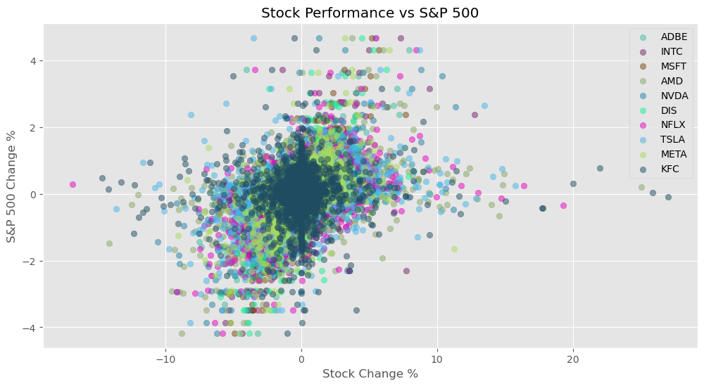

```python
plt.figure(figsize=(12,6))
for stock in stocks:
    plt.scatter(df[stock], df['sp500_changep'], alpha=0.5, label=stock.replace("_changep", ""), color=[np.random.rand(), np.random.rand(), np.random.rand()])
plt.xlabel('Stock Change %')
plt.ylabel('S&P 500 Change %')
plt.title('Stock Performance vs S&P 500')
plt.legend()
plt.show()
```

## Overall Comparison of Individual Stocks

### Correlation Matrix

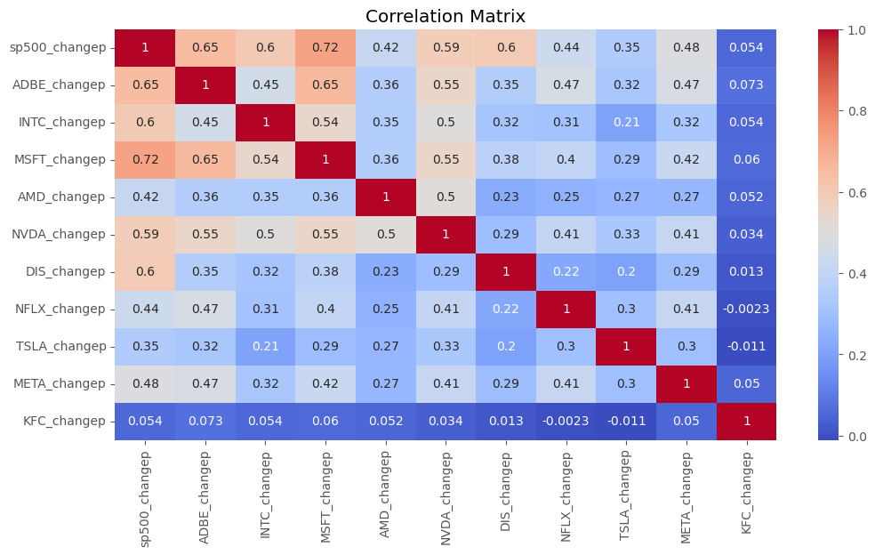

```python
plt.figure(figsize=(12, 6))
sns.heatmap(df[[col for col in df.columns if 'changep' in col]].corr(), annot=True, cmap='coolwarm')
plt.title('Correlation Matrix')
plt.show()
```

## Findings & Insights

Throughought the visualizations here are some of the key insights:

1. Trends and patterns within the S&P 500
2. Entertainment stocks seemed to share a higher increase compared to technology stocks
3. Correlation of different stocks compared to the **S&P 500**

In terms of volatility, the technology stocks seemed to share more frequent and controlled fluctuations within the market sharing periods of higher increases and decreases, sometimes entertainment stocks shared dramatic movements within the market but overall shared a higher daily percentage average in comparision to technology stocks. This could suggest that technology stocks offer more stable growth compared to entertianment stocks with less risk but overall less returms. On the other hand, it seems that entertiainment stocks could give a better return but with more of an aggressive risk.

Lastly, the moving average shows that a sustained deviation from the moving average can precede corrections within the market. This means that the tracking of the moving averages could also help investors anticipate potential downturns or upward predictions in values.

## Impact Section

The insights of this `S&P 500 Analysis` have several broad implications for different interest groups that could benefit from the index such as analysts or investors. Through identifying stocks that correlate strongly with the S&P 500, investors can build more informed portfolios to properly manage their risk or how they would like to receive returns within the market. Additionally understanding sector-wide attributes enables participants within the market to make more informed investment practices based on how they could perceive stability or profit.

On a different perspective, some etchical considerations should be acknowledged. Predictive models based on stock data must be used responsibly, such as levering them for high-frequency trading that could create market issues. Additionally, baises in data collection may skew results, this making it important that findings are based of divers datasets compared to a limited sample.

## References

1. Investopedia. (n.d.). S&P 500 Definition. Retrieved February 2, 2025, from https://www.investopedia.com/terms/s/sp500.asp
2. Investopedia. (n.d.). S&P 500 Definition. Retrieved February 2, 2025, from https://www.investopedia.com/terms/s/sp500.asp
3. Kaggle. (n.d.). S&P 500 Popular Stocks Daily Trends and Change. Retrieved February 1, 2025, from https://www.kaggle.com/datasets/atacs26/s-and-p-500-popular-stocks-daily-trends-and-change/code
4. Seaborn KDE Plot Documentation: Seaborn. (n.d.). seaborn.kdeplot – Kernel Density Estimation plot. Retrieved February 7, 2025, from https://seaborn.pydata.org/generated/seaborn.kdeplot.html
5. Pearson Correlation (ScienceDirect): ScienceDirect. (n.d.). Pearson correlation. Retrieved February 7, 2025, from https://www.sciencedirect.com/topics/computer-science/pearson-correlation
6. W3Schools. (n.d.). Pandas Tutorial. Retrieved February 1, 2025, from https://www.w3schools.com/python/pandas/default.asp